# 401HW2

Group #9: Qiana Yang, Dian Yu, Yijun Wu, Qiaozhen Wu

10/4/2020

## 3.8

#### a.

$$X = \begin{bmatrix} 1 &1\\ 1 & 2 \\1 & 3 \\ 1 & 4 \\ 1& 5\end{bmatrix}$$

#### b.

$$\begin{equation}
\begin{split}
X^{'}X
& = \begin{bmatrix} 1 & 1 & 1 & 1 & 1 \\ 1 & 2 & 3 & 4 & 5\end{bmatrix}
\begin{bmatrix} 1 & 1\\ 1 & 2 \\1 & 3 \\ 1 & 4 \\ 1 & 5\end{bmatrix} \\
& = \begin{bmatrix} 5 & 15 \\ 15 & 55 \end{bmatrix}
\end{split}
\end{equation}$$

$$\begin{equation}
\begin{split}
(X^{'}X )^{-1}
& = \frac{1}{5\times 55-15^2}\begin{bmatrix} 55 & -15 \\ -15 & 5 \end{bmatrix}\\
& = \begin{bmatrix} 1.1 & -0.3 \\ -0.3 & 0.1 \end{bmatrix}
\end{split}
\end{equation}$$

$$\begin{equation}
\begin{split}
\begin{bmatrix} 5 & 15 \\ 15 & 55 \end{bmatrix} \begin{bmatrix} 1.1 & -0.3 \\ -0.3 & 0.1 \end{bmatrix}
& = \begin{bmatrix} (5)(1.1)+(15)(-0.3) & (5)(-0.3)+(15)(0.1) \\ (15)(1.1)+(55)(-0.3) & (15)(-0.3)+(55)(0.1) \end{bmatrix} \\
& = \begin{bmatrix} 1 & 0 \\ 0 & 1 \end{bmatrix}
\end{split}
\end{equation}$$

#### c.

$$\begin{equation}
\begin{split}
X^{'}Y
& = \begin{bmatrix} 1 & 1 & 1 & 1 & 1 \\ 1 & 2 & 3 & 4 & 5 \end{bmatrix} \begin{bmatrix} 2 \\ 6 \\ 7 \\ 9 \\ 10 \end{bmatrix} \\
& = \begin{bmatrix} 34 \\ 121 \end{bmatrix}
\end{split}
\end{equation}$$

#### d.

$$\begin{equation}
\begin{split}
\begin{bmatrix} \hat\beta_0 \\ \hat\beta_1 \end{bmatrix}
& = (X^{'}X)^{-1}XY \\
& = \begin{bmatrix} 1.1 & -0.3 \\ -0.3 & 0.1 \end{bmatrix} \begin{bmatrix} 34 \\ 121 \end{bmatrix} \\
& = \begin{bmatrix} 1.1 \\ 1.9 \end{bmatrix}
\end{split}
\end{equation}$$

## 3.9

$\beta_0-\beta_1-\beta_2 +\beta_3= 40$

$\beta_0+\beta_1-\beta_2 - \beta_3= 40+5$

$\beta_0-\beta_1+\beta_2 - \beta_3= 40+10$

$\beta_0+\beta_1+\beta_2 + \beta_3 = 65$

$\beta_0 = 50, \beta_1 = 5, \beta_2 = 7.5, \beta_3 = 2.5$

Interpretation: $\beta_0$ could be considered as the mean salary between all combinations of demographics (white + male, non-white + male, white + female, non-white + female). The $\beta$s’ in this regression model signify how much each demographic deviates from the mean when interaction is taken into account.

## 3.10

#### a) Fit the Cobb-Douglas production function by log transformation.

```r
cd_data <- read.csv(here::here("Cobb-Douglas.csv"))[,-1]
head(cd_data)
```

```
##      capital labor     output
## 1   2.606563   184   9.250759
## 2   1.323237    91   3.664310
## 3  22.093692   426  28.781516
## 4  10.737851    72   4.124642
## 5   1.161365    46   2.890150
## 6 276.796701  7642 480.140372
```

```r
cd_fit <- lm(log(output) ~ log(capital) + log(labor), cd_data)
summary(cd_fit)
```

```
##
## Call:
## lm(formula = log(output) ~ log(capital) + log(labor), data = cd_data)
##
## Residuals:
##     Min      1Q  Median      3Q     Max
## -1.7604 -0.2665 -0.0694  0.1926  3.7975
##
## Coefficients:
##              Estimate Std. Error t value Pr(>|t|)
## (Intercept)  -1.71146    0.09671  -17.70   <2e-16 ***
## log(capital)  0.20757    0.01719   12.08   <2e-16 ***
## log(labor)    0.71485    0.02314   30.89   <2e-16 ***
## ---
## Signif. codes:  0 '***' 0.001 '**' 0.01 '*' 0.05 '.' 0.1 ' ' 1
##
## Residual standard error: 0.4781 on 566 degrees of freedom
## Multiple R-squared:  0.8378, Adjusted R-squared:  0.8373
## F-statistic:  1462 on 2 and 566 DF,  p-value: < 2.2e-16
```

#### b) test constant returns to scale

```r
beta1_hat <- coef(cd_fit)[2]
beta2_hat <- coef(cd_fit)[3]
var_cap <- vcov(cd_fit)[2,2]
var_lab <- vcov(cd_fit)[3,3]
cov_caplab <- vcov(cd_fit)[2,3]

t <- (beta1_hat + beta2_hat - 1)/sqrt(var_cap + var_lab + 2 * cov_caplab)
t
```

```
## log(capital)
##     -4.50945
```

```r
abs(t) > qt(1 - 0.05/2, df = nrow(cd_data) - 3)
```

```
## log(capital)
##         TRUE
```

```r
# t statistic is greater than the critical value, so the result is significant. We reject the null hypothesis that beta1 + beta2 = 1.
```

#### c) alternative t test

```r
cd_data$alt_y <- log(cd_data$output) - log(cd_data$labor)
cd_data$alt_x1 <- log(cd_data$capital) - log(cd_data$labor)

alt_fit <- lm(alt_y ~ alt_x1 + log(labor), cd_data)

summary(alt_fit)
```

```
##
## Call:
## lm(formula = alt_y ~ alt_x1 + log(labor), data = cd_data)
##
## Residuals:
##     Min      1Q  Median      3Q     Max
## -1.7604 -0.2665 -0.0694  0.1926  3.7975
##
## Coefficients:
##             Estimate Std. Error t value Pr(>|t|)
## (Intercept) -1.71146    0.09671 -17.697  < 2e-16 ***
## alt_x1       0.20757    0.01719  12.077  < 2e-16 ***
## log(labor)  -0.07758    0.01720  -4.509  7.9e-06 ***
## ---
## Signif. codes:  0 '***' 0.001 '**' 0.01 '*' 0.05 '.' 0.1 ' ' 1
##
## Residual standard error: 0.4781 on 566 degrees of freedom
## Multiple R-squared:  0.2393, Adjusted R-squared:  0.2366
## F-statistic: 89.03 on 2 and 566 DF,  p-value: < 2.2e-16
```

```r
# the result is significant, and it is the same as that obtained in Part(b). Note that the t score obtained in Part(b) equals the t score of x2 here. The t score of x2 is significant, and therefore we reject the null hypothesis that beta1 + beta2 - 1 = 0.
```

## 3.11

#### a) plot scatter matrix, find correlation matrix of research expenditures, number of faculty, and number of PhD students

```r
research <- read.csv('Research.csv')
library("PerformanceAnalytics")
```

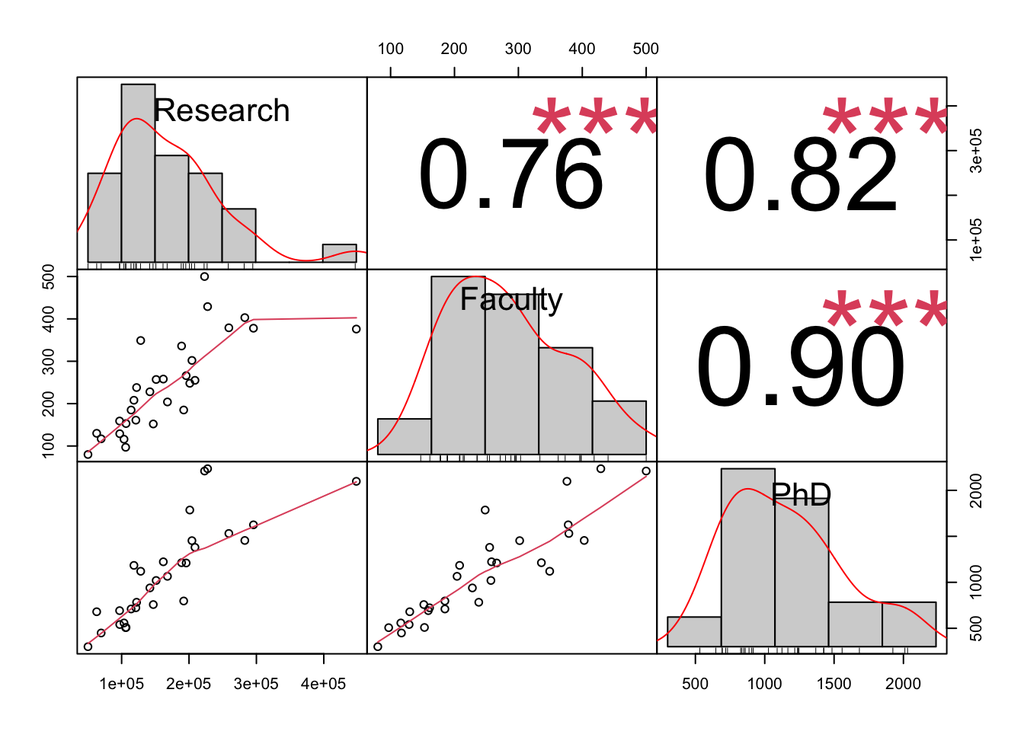

```r
research$Research <- gsub("\\$" , "", research$Research)
research$Research <- as.numeric(gsub("\\," , "", research$Research))
chart.Correlation(research[,c(2,3,5)], histogram=TRUE, pch=19)
```

```r
cor(research[,c(2,3,5)])
```

```
##           Research   Faculty       PhD
## Research 1.0000000 0.7648421 0.8174254
## Faculty  0.7648421 1.0000000 0.9036829
## PhD      0.8174254 0.9036829 1.0000000
```

```r
# the number of PhD students is highly correlated with the number of faculty, with r = 0.90. Research expenditure is correlated with the number of PhD students and faculty with r = 0.82 and r = 0.76 respectively.
```

#### b) fit a regression model for Research versus Faculty and PhD.

```r
res_fit <- lm(Research ~ Faculty + PhD, research)
summary(res_fit)
```

```
##
## Call:
## lm(formula = Research ~ Faculty + PhD, data = research)
##
## Residuals:
##    Min     1Q Median     3Q    Max
## -90804 -16921  -2921  13605 159743
##
## Coefficients:
##             Estimate Std. Error t value Pr(>|t|)
## (Intercept) 23525.91   22034.47   1.068   0.2951
## Faculty       107.13     193.39   0.554   0.5842
## PhD           107.14      40.06   2.675   0.0125 *
## ---
## Signif. codes:  0 '***' 0.001 '**' 0.01 '*' 0.05 '.' 0.1 ' ' 1
##
## Residual standard error: 49040 on 27 degrees of freedom
## Multiple R-squared:  0.6719, Adjusted R-squared:  0.6476
## F-statistic: 27.65 on 2 and 27 DF,  p-value: 2.923e-07
```

```r
head(research)
```

```
##   University Research Faculty PhD.Faculty  PhD
## 1        MIT   448324     376        5.58 2098
## 2   Stanford   201160     248        7.20 1786
## 3   Berkeley   208862     255        5.41 1380
## 4    CalTech   105985      97        5.23  507
## 5        CMU   195765     266        4.55 1210
## 6   Michigan   295646     378        4.30 1625
```

```r
try1 <- lm(Research ~ Faculty, research)
summary(try1)
```

```
##
## Call:
## lm(formula = Research ~ Faculty, data = research)
##
## Residuals:
##    Min     1Q Median     3Q    Max
## -99318 -24416  -6235  23564 205190
##
## Coefficients:
##             Estimate Std. Error t value Pr(>|t|)
## (Intercept) 27100.96   24290.89   1.116    0.274
## Faculty       574.56      91.46   6.282 8.59e-07 ***
## ---
## Signif. codes:  0 '***' 0.001 '**' 0.01 '*' 0.05 '.' 0.1 ' ' 1
##
## Residual standard error: 54160 on 28 degrees of freedom
## Multiple R-squared:  0.585,  Adjusted R-squared:  0.5702
## F-statistic: 39.47 on 1 and 28 DF,  p-value: 8.592e-07
```

```r
try2 <- lm(Research ~ PhD, research)
summary(try2)
```

```
##
## Call:
## lm(formula = Research ~ PhD, data = research)
##
## Residuals:
##    Min     1Q Median     3Q    Max
## -85652 -17918  -1532  14111 153858
##
## Coefficients:
##             Estimate Std. Error t value Pr(>|t|)
## (Intercept) 27622.20   20498.20   1.348    0.189
## PhD           127.19      16.94   7.509 3.53e-08 ***
## ---
## Signif. codes:  0 '***' 0.001 '**' 0.01 '*' 0.05 '.' 0.1 ' ' 1
##
## Residual standard error: 48430 on 28 degrees of freedom
## Multiple R-squared:  0.6682, Adjusted R-squared:  0.6563
## F-statistic: 56.38 on 1 and 28 DF,  p-value: 3.529e-08
```

```r
# The number of faculty is highly correlated with the number of students (r = 0.9). In this case, research expenditures are also calculated by weighing both total research expenditures and research expenditures by faculty. Given faculty with more research grant funds more students and the number of faculty can be estimated by total research expenditures / research expenditures by faculty, the relationship between faculty and student is not independent, and therefore the model we have here has a multicollinearity problem.
```

## 3.12

```r
R <- rbind(c(1, 0.5), c(0.5, 1))
r <- c(0.4, 0.8)
beta_hat_star <- solve(R)%*%r

#standardized regression coefficients:
beta_hat_star
```

```
##      [,1]
## [1,]  0.0
## [2,]  0.8
```

```r
beta_1 = beta_hat_star[1, 1]*5/2
beta_2 = beta_hat_star[2, 1]*5/4
beta_0 = 10-(beta_1*3+beta_2*5)
beta_unstand <- c("beta_0" = beta_0, "beta_1" = beta_1, "beta_2" = beta_2)
beta_unstand
```

```
## beta_0 beta_1 beta_2
##      5      0      1
```

The regression model is $y = x_2 + 5$

## 3.14

#### a) Fit prediction model - set male and purchase as the reference variables

```r
salaries <- read.csv(here::here("salaries.csv"), stringsAsFactors = T)

head(salaries)
```

```
##   Salary YrsEm PriorYr Education  ID Gender  Dept Super
## 1  38985    18       7         9 412 Female Sales     5
## 2  32920    15       3         9 458   Male Sales     4
## 3  29548     5       6         1 604 Female Sales     0
## 4  24749     6       2         0 598   Male Sales     1
## 5  41889    22      16         7 351 Female Sales     7
## 6  31528     3      11         3 674 Female Sales     6
```

```r
salaries$Gender <- relevel(salaries$Gender, "Male")
salaries$Dept <- relevel(salaries$Dept, "Purchase")
salfit <- lm(log10(Salary)~YrsEm + PriorYr + Education + Super + Gender + Dept, salaries)

summary(salfit)
```

```
##
## Call:
## lm(formula = log10(Salary) ~ YrsEm + PriorYr + Education + Super +
##     Gender + Dept, data = salaries)
##
## Residuals:
##       Min        1Q    Median        3Q       Max
## -0.089659 -0.024036 -0.004498  0.028587  0.089410
##
## Coefficients:
##                Estimate Std. Error t value Pr(>|t|)
## (Intercept)   4.4287934  0.0213399 207.535  < 2e-16 ***
## YrsEm         0.0074788  0.0011931   6.269 2.72e-07 ***
## PriorYr       0.0016839  0.0019568   0.861 0.395039
## Education     0.0170345  0.0033360   5.106 1.02e-05 ***
## Super         0.0003901  0.0008056   0.484 0.631115
## GenderFemale  0.0230683  0.0142917   1.614 0.115002
## DeptAdvertse -0.0387774  0.0249146  -1.556 0.128124
## DeptEngineer -0.0057292  0.0197703  -0.290 0.773597
## DeptSales    -0.0937783  0.0225745  -4.154 0.000185 ***
## ---
## Signif. codes:  0 '***' 0.001 '**' 0.01 '*' 0.05 '.' 0.1 ' ' 1
##
## Residual standard error: 0.04586 on 37 degrees of freedom
## Multiple R-squared:  0.8634, Adjusted R-squared:  0.8338
## F-statistic: 29.22 on 8 and 37 DF,  p-value: 9.629e-14
```

#### b) set female and sales as the new reference categories

```r
salaries$Gender <- relevel(salaries$Gender, "Female")
salaries$Dept <- relevel(salaries$Dept, "Sales")
salfit2 <- lm(log10(Salary)~YrsEm + PriorYr + Education + Super + Gender + Dept, salaries)

summary(salfit2)
```

```
##
## Call:
## lm(formula = log10(Salary) ~ YrsEm + PriorYr + Education + Super +
##     Gender + Dept, data = salaries)
##
## Residuals:
##       Min        1Q    Median        3Q       Max
## -0.089659 -0.024036 -0.004498  0.028587  0.089410
##
## Coefficients:
##                Estimate Std. Error t value Pr(>|t|)
## (Intercept)   4.3580834  0.0248414 175.436  < 2e-16 ***
## YrsEm         0.0074788  0.0011931   6.269 2.72e-07 ***
## PriorYr       0.0016839  0.0019568   0.861 0.395039
## Education     0.0170345  0.0033360   5.106 1.02e-05 ***
## Super         0.0003901  0.0008056   0.484 0.631115
## GenderMale   -0.0230683  0.0142917  -1.614 0.115002
## DeptPurchase  0.0937783  0.0225745   4.154 0.000185 ***
## DeptAdvertse  0.0550009  0.0230111   2.390 0.022045 *
## DeptEngineer  0.0880491  0.0180562   4.876 2.07e-05 ***
## ---
## Signif. codes:  0 '***' 0.001 '**' 0.01 '*' 0.05 '.' 0.1 ' ' 1
##
## Residual standard error: 0.04586 on 37 degrees of freedom
## Multiple R-squared:  0.8634, Adjusted R-squared:  0.8338
## F-statistic: 29.22 on 8 and 37 DF,  p-value: 9.629e-14
```

```r
# coefficient for male is -0.023, opposite to what we got for female in a).
# coefficients for Purchase, Advertising, and Engineering are 0.0938, 0.0550, 0.0880 respectively.
```

#### c) predict a person’s salary based on criteria below

```r
predict1 <- predict(salfit, newdata = data.frame(YrsEm = 8, PriorYr = 10, Education = 12, Gender = "Male", Dept = "Sales", Super = 5), interval = "prediction")

10^c(predict1)
```

```
## [1] 41500.04 31937.20 53926.24
```

```r
# the salary would be $41500.04, with lower bound $31937.20 and upper bound $53926.24.
```

#### d) The coefficient of Engg is highly nonsignificant with a P-value = 0.774 in the above regression. But if Sales is used as the reference category, the coefficient of Engg is highly significant with a P-value < 0:001. Interpret this result.

Answer: the salaries of those from the Engineering Dept are not significantly different from those from the Purchase Dept, but they are significantly different from those from the Sales Dept.

#### e) In the above model, the coefficient of Female is nonsignificant with P = 0.115, so there is not a significant difference between the salaries of Males and Females, controlling for other variables. Should we drop Gender as a predictor variable? For Dept the question is more complicated since the coefficients of Advert and Engg are nonsignificant but the coefficient of Sales in highly significant with P = 0.0002. Should the nonsignificant categories, Advert and Engg, be pooled with the reference category, Purchase, or should the categories be left unpooled or should the Dept be dropped as a predictor variable?

Answer: We may drop gender as a predictor variable because there is no significant difference between the two genders. Since the coefficient of Sales is significant, we should not pool the nonsignificant categories with the reference category, because otherwise we would lose information when changing reference categories. Dept should not be dropped as a predictor variable, because at least one of the dummy variables is significant.